# Analyses for Susa (2016) mark-recapture study

Johanna Kiss et al.

2023-12-07

### Describing movement of different sized males and females in Lethrus beetles on field by using one model.

##### Using 1 model for each response variable (e.g., number of recaptures, travelled distances…) instead of 2.

##### To do that we reanalyse data and test the effect of the created 4-level factor ( female, small male, middle male, large male)

```r
all.dist<-read.csv(file="rel.full.data.csv",header=TRUE,nrow=FALSE)
all.capt<-read.csv(file="rel.aa.df.data.csv",header=TRUE,nrow=FALSE)
```

```r
head(all.dist)
```

```
##   id no.cap sex     age     aktiv       date cap.recap comment  x.coord
## 1  3      2   f juvenil           2016-03-30         r    died 738887.6
## 2 35      2   f juvenil       dig 2016-03-21         r         738822.9
## 3 37      3   f juvenil travelled 2016-03-30         r         738782.8
## 4 37      4   f juvenil travelled 2016-04-07         r         738782.4
## 5 46      2   f juvenil     dicon 2016-05-02         r         738906.5
## 6 48      3   f juvenil      nest 2016-03-31         r         738813.3
##    y.coord elev.map.b Distance  body proc date.of.catch id.1 diff.days
## 1 326513.5   221.0469 1.692479 12.09    0    2016-03-17    3        13
## 2 326585.9   243.7310 2.023965 12.20    0    2016-03-18   35         3
## 3 326601.2   248.3841 9.403658 10.69    0    2016-03-18   37        12
## 4 326607.9   248.0072 6.789462 10.69    0    2016-03-18   37         8
## 5 326539.9   225.3828 5.441226 10.67    0    2016-03-21   46        42
## 6 326583.9   239.7425 2.813426 11.71    0    2016-03-21   48         9
##   rel.bodywidth    st.date day day.from.1st.catch
## 1    0.50708209 2016-03-17  13                  0
## 2    0.66352686 2016-03-17   4                  1
## 3   -1.48403316 2016-03-17  13                  1
## 4   -1.48403316 2016-03-17  21                  1
## 5   -1.51247766 2016-03-17  46                  4
## 6   -0.03336348 2016-03-17  14                  4
```

```r
head(all.capt)
```

```
##    X ID sex B.width Tusk days     Age no.recaptures  tot.dist  max.dist
## 1  1  3   f   12.09    0   13 juvenil             1  1.692479  1.692479
## 2  5 35   f   12.20    0    3 juvenil             1  2.023965  2.023965
## 3  7 37   f   10.69    0   20 juvenil             2 16.193120  9.403658
## 4  9 46   f   10.67    0   42 juvenil             1  5.441226  5.441226
## 5 10 48   f   11.71    0   10 juvenil             2  5.086223  2.813426
## 6 14 55   f   11.97    0   23     old             6 34.572775 21.058028
##   dist.a.day rel.bodywidth
## 1  0.1301907    0.49249005
## 2  0.6746550    0.64981503
## 3  0.8096560   -1.50982789
## 4  0.1295530   -1.53843243
## 5  0.5086223   -0.05099625
## 6  1.5031642    0.32086280
```

##### Previously, based on a segmented regression on body size we determined the breakpoints, now we use them to create male categories:

```r
library(dplyr)
new.all.capt<-all.capt%>%
  mutate(sex.cat= case_when(sex=="m" & B.width <= 10.68 ~ 'small.male',
                            sex=="m" & B.width > 12.32 ~ 'large.male',
                            sex=="m" & B.width > 10.68 & B.width <= 12.32 ~ 'middle.male',
                            sex=="f" ~ 'female'))
```

```r
library(dplyr)
new.all.dist<-all.dist%>%
  mutate(sex.cat= case_when(sex=="m" & body <= 10.68 ~ 'small.male',
                            sex=="m" & body > 12.32 ~ 'large.male',
                            sex=="m" & body > 10.68 & body <= 12.32 ~ 'middle.male',
                            sex=="f" ~ 'female'))
```

##### Load some packages:

```r
library(plotrix)
library(emmeans)
library(plyr)
library(dplyr)
library(ggplot2)
library(scales)
library(MASS)
library(lme4)
library(pbkrtest)
library(pscl)
library(lattice)
library(partR2)
library(rsq)
library(segmented)
library(ggplot2)
library(interactions)
library(jtools)
library(bbmle)
```

#### New analyses on the number of recaptures

```r
str(new.all.capt)
```

```
## 'data.frame':    1624 obs. of  13 variables:
##  $ X            : int  1 5 7 9 10 14 16 18 22 28 ...
##  $ ID           : int  3 35 37 46 48 55 57 68 72 92 ...
##  $ sex          : chr  "f" "f" "f" "f" ...
##  $ B.width      : num  12.1 12.2 10.7 10.7 11.7 ...
##  $ Tusk         : num  0 0 0 0 0 0 0 0 0 0 ...
##  $ days         : int  13 3 20 42 10 23 22 26 8 43 ...
##  $ Age          : chr  "juvenil" "juvenil" "juvenil" "juvenil" ...
##  $ no.recaptures: int  1 1 2 1 2 6 11 2 2 1 ...
##  $ tot.dist     : num  1.69 2.02 16.19 5.44 5.09 ...
##  $ max.dist     : num  1.69 2.02 9.4 5.44 2.81 ...
##  $ dist.a.day   : num  0.13 0.675 0.81 0.13 0.509 ...
##  $ rel.bodywidth: num  0.492 0.65 -1.51 -1.538 -0.051 ...
##  $ sex.cat      : chr  "female" "female" "female" "female" ...
```

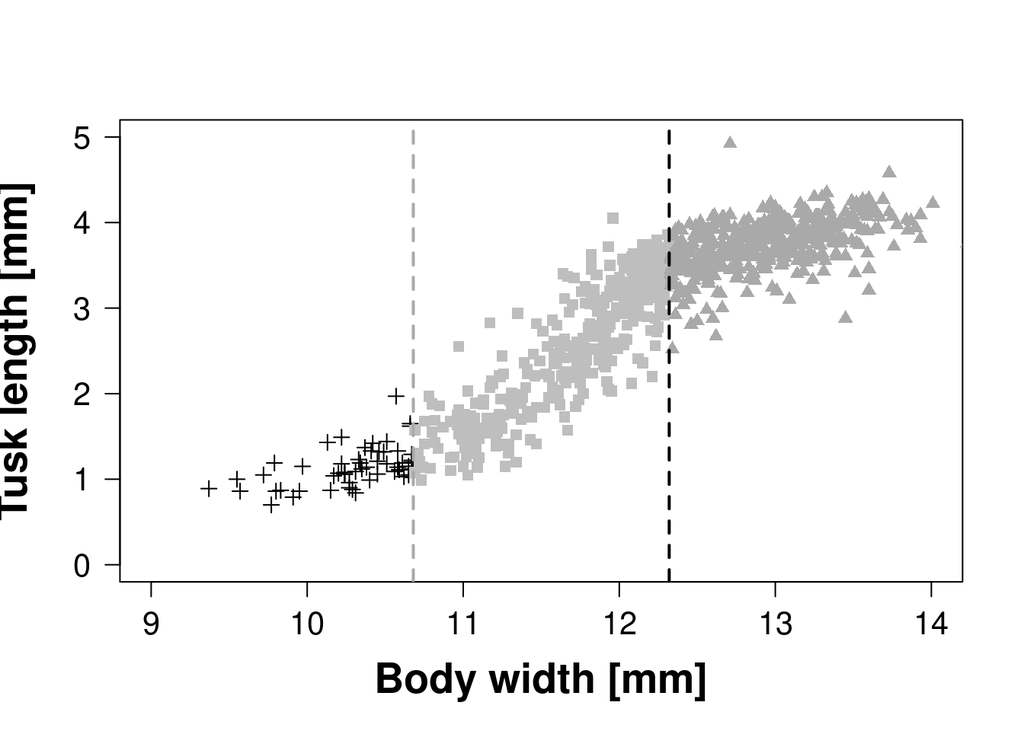

```r
new.all.capt.m<-new.all.capt[new.all.capt$sex=="m",]

new.all.capt.m<-new.all.capt[!new.all.capt$Tusk==0,]




custom_pch <- c(3,15,17)

plot(new.all.capt.m$Tusk~new.all.capt.m$B.width, type="n", xlab="Body width [mm]", ylab="Tusk length [mm]",las=1,  cex.axis=1.3, cex=1, cex.lab=1.7, las=1, font.lab=2.3, font.main=4.3, ylim=c(0, 5),xlim=c(9,14))
points(new.all.capt.m$Tusk~new.all.capt.m$B.width, subset=new.all.capt.m$sex.cat=="small.male", pch=3,
       col=1)
points(new.all.capt.m$Tusk~new.all.capt.m$B.width, subset=new.all.capt.m$sex.cat=="middle.male", pch=15,
       col="grey")

points(new.all.capt.m$Tusk~new.all.capt.m$B.width, subset=new.all.capt.m$sex.cat=="large.male", pch=17,
       col="darkgrey")

abline(v=c(10.68, 12.32), col=c("darkgrey", "black"), lty=2, lwd=2)
```

##### Lets see the models:

```r
new.p.rec<-glm(no.recaptures~sex.cat,new.all.capt,family=poisson)
drop1(new.p.rec,test="Chisq")
```

```
## Single term deletions
##
## Model:
## no.recaptures ~ sex.cat
##         Df Deviance    AIC    LRT  Pr(>Chi)
## <none>       2272.6 3164.9
## sex.cat  3   2310.6 3196.9 38.069 2.734e-08 ***
## ---
## Signif. codes:  0 '***' 0.001 '**' 0.01 '*' 0.05 '.' 0.1 ' ' 1
```

```r
new.qp.rec<-glm(no.recaptures~sex.cat,new.all.capt,family=quasipoisson)
drop1(new.qp.rec,test="Chisq")
```

```
## Single term deletions
##
## Model:
## no.recaptures ~ sex.cat
##         Df Deviance scaled dev. Pr(>Chi)
## <none>       2272.6
## sex.cat  3   2310.6       14.52 0.002276 **
## ---
## Signif. codes:  0 '***' 0.001 '**' 0.01 '*' 0.05 '.' 0.1 ' ' 1
```

```r
new.zp.rec<-zeroinfl(no.recaptures~sex.cat,new.all.capt,dist='poisson')
drop1(new.zp.rec,test="Chisq")
```

```
## Single term deletions
##
## Model:
## no.recaptures ~ sex.cat
##         Df    AIC   LRT  Pr(>Chi)
## <none>     2797.4
## sex.cat  6 2816.2 30.81 2.756e-05 ***
## ---
## Signif. codes:  0 '***' 0.001 '**' 0.01 '*' 0.05 '.' 0.1 ' ' 1
```

```r
new.znb.rec<-zeroinfl(no.recaptures~sex.cat,new.all.capt,dist='negbin')
drop1(new.znb.rec,test="Chisq")
```

```
## Single term deletions
##
## Model:
## no.recaptures ~ sex.cat
##         Df    AIC    LRT Pr(>Chi)
## <none>     2673.3
## sex.cat  6 2677.7 16.391   0.0118 *
## ---
## Signif. codes:  0 '***' 0.001 '**' 0.01 '*' 0.05 '.' 0.1 ' ' 1
```

```r
new.hnb.rec<-hurdle(no.recaptures~sex.cat,new.all.capt,dist='negbin')
drop1(new.hnb.rec,test="Chisq")
```

```
## Single term deletions
##
## Model:
## no.recaptures ~ sex.cat
##         Df    AIC    LRT Pr(>Chi)
## <none>     2661.1
## sex.cat  6 2668.5 19.349 0.003612 **
## ---
## Signif. codes:  0 '***' 0.001 '**' 0.01 '*' 0.05 '.' 0.1 ' ' 1
```

```r
new.nb.rec<-glm.nb(no.recaptures~sex.cat,new.all.capt)
drop1(new.nb.rec,test="Chisq")
```

```
## Single term deletions
##
## Model:
## no.recaptures ~ sex.cat
##         Df Deviance    AIC    LRT  Pr(>Chi)
## <none>       978.69 2663.3
## sex.cat  3   995.30 2673.9 16.605 0.0008521 ***
## ---
## Signif. codes:  0 '***' 0.001 '**' 0.01 '*' 0.05 '.' 0.1 ' ' 1
```

##### Lets compare the models

```r
logLik(new.p.rec)
```

```
## 'log Lik.' -1578.433 (df=4)
```

```r
logLik(new.nb.rec)
```

```
## 'log Lik.' -1327.664 (df=5)
```

```r
logLik(new.hnb.rec)
```

```
## 'log Lik.' -1321.566 (df=9)
```

```r
logLik(new.znb.rec)
```

```
## 'log Lik.' -1327.664 (df=9)
```

```r
logLik(new.zp.rec)
```

```
## 'log Lik.' -1390.68 (df=8)
```

```r
logLik(new.qp.rec)
```

```
## 'log Lik.' NA (df=5)
```

```r
AIC(new.p.rec)
```

```
## [1] 3164.865
```

```r
AIC(new.nb.rec)
```

```
## [1] 2665.328
```

```r
AIC(new.hnb.rec)
```

```
## [1] 2661.132
```

```r
AIC(new.znb.rec)
```

```
## [1] 2673.328
```

```r
AIC(new.zp.rec)
```

```
## [1] 2797.361
```

```r
AIC(new.qp.rec)
```

```
## [1] NA
```

##### HNB and NB models seemed to be the best.

```r
drop1(new.hnb.rec,test="Chisq")
```

```
## Single term deletions
##
## Model:
## no.recaptures ~ sex.cat
##         Df    AIC    LRT Pr(>Chi)
## <none>     2661.1
## sex.cat  6 2668.5 19.349 0.003612 **
## ---
## Signif. codes:  0 '***' 0.001 '**' 0.01 '*' 0.05 '.' 0.1 ' ' 1
```

```r
drop1(new.nb.rec,test="Chisq")
```

```
## Single term deletions
##
## Model:
## no.recaptures ~ sex.cat
##         Df Deviance    AIC    LRT  Pr(>Chi)
## <none>       978.69 2663.3
## sex.cat  3   995.30 2673.9 16.605 0.0008521 ***
## ---
## Signif. codes:  0 '***' 0.001 '**' 0.01 '*' 0.05 '.' 0.1 ' ' 1
```

```r
ph.test.rec<-emmeans(new.nb.rec, ~sex.cat,type="response")
test(ph.test.rec)
```

```
##  sex.cat     response     SE  df null z.ratio p.value
##  female         0.330 0.0293 Inf    1 -12.504  <.0001
##  large.male     0.533 0.0587 Inf    1  -5.716  <.0001
##  middle.male    0.497 0.0591 Inf    1  -5.874  <.0001
##  small.male     0.236 0.0867 Inf    1  -3.933  0.0001
##
## Tests are performed on the log scale
```

```r
pairs(ph.test.rec)
```

```
##  contrast                 ratio     SE  df null z.ratio p.value
##  female / large.male      0.620 0.0877 Inf    1  -3.384  0.0040
##  female / middle.male     0.664 0.0984 Inf    1  -2.765  0.0291
##  female / small.male      1.396 0.5267 Inf    1   0.884  0.8131
##  large.male / middle.male 1.071 0.1737 Inf    1   0.422  0.9747
##  large.male / small.male  2.253 0.8627 Inf    1   2.121  0.1463
##  middle.male / small.male 2.104 0.8111 Inf    1   1.929  0.2157
##
## P value adjustment: tukey method for comparing a family of 4 estimates
## Tests are performed on the log scale
```

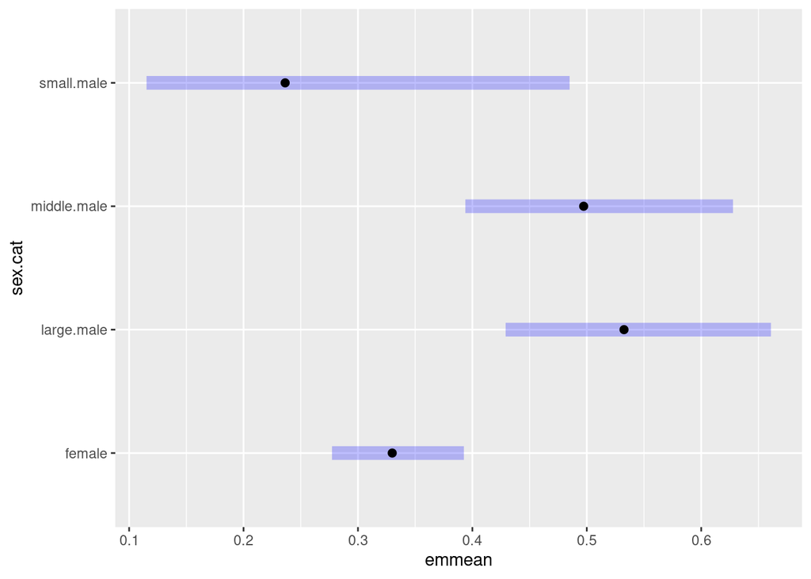

```r
plot(ph.test.rec)
```

```r
ph.test.rec2<-emmeans(new.nb.rec, ~sex.cat,type="link")
test(ph.test.rec2)
```

```
##  sex.cat     emmean     SE  df z.ratio p.value
##  female      -1.109 0.0887 Inf -12.504  <.0001
##  large.male  -0.630 0.1102 Inf  -5.716  <.0001
##  middle.male -0.699 0.1189 Inf  -5.874  <.0001
##  small.male  -1.442 0.3667 Inf  -3.933  0.0001
##
## Results are given on the log (not the response) scale.
```

```r
pairs(ph.test.rec2)
```

```
##  contrast                 estimate    SE  df z.ratio p.value
##  female - large.male       -0.4787 0.141 Inf  -3.384  0.0040
##  female - middle.male      -0.4102 0.148 Inf  -2.765  0.0291
##  female - small.male        0.3336 0.377 Inf   0.884  0.8131
##  large.male - middle.male   0.0685 0.162 Inf   0.422  0.9747
##  large.male - small.male    0.8123 0.383 Inf   2.121  0.1463
##  middle.male - small.male   0.7438 0.386 Inf   1.929  0.2157
##
## Results are given on the log (not the response) scale.
## P value adjustment: tukey method for comparing a family of 4 estimates
```

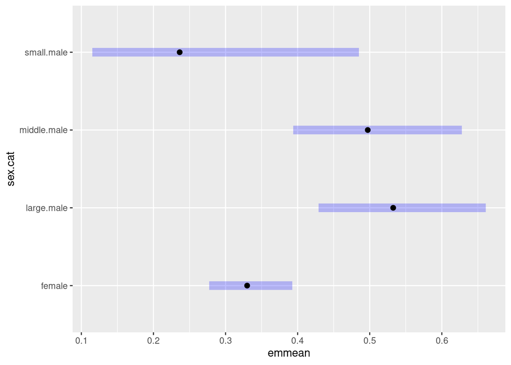

```r
plot(ph.test.rec)
```

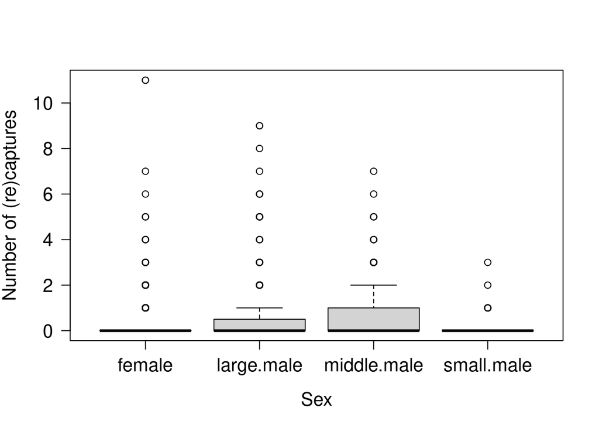

```r
boxplot(new.all.capt$no.recaptures~new.all.capt$sex.cat,xlab="Sex",ylab="Number of (re)captures",las=1, lwd=1,font.lab=2, cex.lab=1.3,cex.axis=1.3,font.main=2)
```

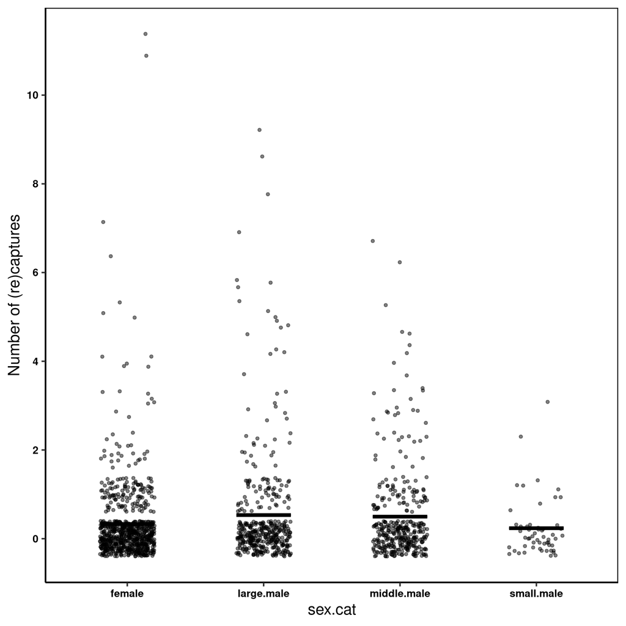

```r
new1<-ggplot(new.all.capt,aes(sex.cat,no.recaptures),line.thickness=1.2) +theme_classic(base_size = 18) + geom_jitter(width=0.2,alpha=0.5)+scale_y_continuous(name="Number of (re)captures",breaks= pretty_breaks()) +theme (axis.text.x = element_text(face = "bold", size=12,colour="black"), axis.text.y = element_text(face = "bold", size = 12,colour="black"),panel.border= element_rect(color = "black",fill=NA,size=1), legend.text=element_text(size=14),legend.title=element_text(size=16))
new.plot1<-new.all.capt[,c(8,13)]
new.plot1.sum<-aggregate(.~sex.cat,mean,data=new.plot1)



new1+ theme(plot.title.position = "plot")+geom_crossbar(data=new.plot1.sum, aes(ymin=no.recaptures,ymax=no.recaptures),size=0.8,width=0.4)
```

##### Lets see now the effect size:

```r
rsq.partial(new.nb.rec,type='kl')
```

```
## $adjustment
## [1] FALSE
##
## $variable
## [1] "sex.cat"
##
## $partial.rsq
## [1] 0.01668316
```

##### We can calculate R2 values for Hurdle models by using the function r2_zeroinflated of performance package. It is used for models with zero-inflation component, including mixed effects models. Hurdle and zeroinfl functions by Achim Zeileis

```r
library(performance)
r2_zeroinflated(new.hnb.rec)
```

```
## # R2 for Zero-Inflated and Hurdle Regression
##        R2: 0.009
##   adj. R2: 0.006
```

#### New analyses on the number of days

##### Lets see the models:

```r
new.p.days<-glm(days~(sex.cat*no.recaptures)^2,new.all.capt,family=poisson,subset=new.all.capt$no.recaptures>0)
drop1(new.p.days,test="Chisq")
```

```
## Single term deletions
##
## Model:
## days ~ (sex.cat * no.recaptures)^2
##                       Df Deviance    AIC    LRT Pr(>Chi)
## <none>                     2443.2 3840.6
## sex.cat:no.recaptures  3   2448.3 3839.7 5.1447   0.1615
```

```r
new.p.days1<-update(new.p.days,.~.-sex.cat:no.recaptures)
drop1(new.p.days1,test="Chisq")
```

```
## Single term deletions
##
## Model:
## days ~ sex.cat + no.recaptures
##               Df Deviance    AIC     LRT  Pr(>Chi)
## <none>             2448.3 3839.7
## sex.cat        3   2498.9 3884.3  50.544 6.117e-11 ***
## no.recaptures  1   2658.5 4047.9 210.149 < 2.2e-16 ***
## ---
## Signif. codes:  0 '***' 0.001 '**' 0.01 '*' 0.05 '.' 0.1 ' ' 1
```

```r
new.qp.days<-glm(days~(sex.cat*no.recaptures)^2,new.all.capt,family=quasipoisson,subset=new.all.capt$no.recaptures>0)
drop1(new.qp.days,test="Chisq")
```

```
## Single term deletions
##
## Model:
## days ~ (sex.cat * no.recaptures)^2
##                       Df Deviance scaled dev. Pr(>Chi)
## <none>                     2443.2
## sex.cat:no.recaptures  3   2448.3     0.72237   0.8679
```

```r
new.qp.days1<-update(new.qp.days,.~.-sex.cat:no.recaptures)
drop1(new.qp.days1,test="Chisq")
```

```
## Single term deletions
##
## Model:
## days ~ sex.cat + no.recaptures
##               Df Deviance scaled dev.  Pr(>Chi)
## <none>             2448.3
## sex.cat        3   2498.9      7.1527   0.06719 .
## no.recaptures  1   2658.5     29.7388 4.943e-08 ***
## ---
## Signif. codes:  0 '***' 0.001 '**' 0.01 '*' 0.05 '.' 0.1 ' ' 1
```

```r
new.zp.days<-zeroinfl(days~(sex.cat*no.recaptures)^2,new.all.capt,dist='poisson',subset=new.all.capt$no.recaptures>0)
drop1(new.zp.days,test="Chisq")
```

```
## Single term deletions
##
## Model:
## days ~ (sex.cat * no.recaptures)^2
##                       Df    AIC    LRT Pr(>Chi)
## <none>                   3676.9
## sex.cat:no.recaptures  6 3668.5 3.5121   0.7424
```

```r
new.zp.days1<-update(new.zp.days,.~.-sex.cat:no.recaptures)
drop1(new.zp.days1,test="Chisq")
```

```
## Single term deletions
##
## Model:
## days ~ sex.cat + no.recaptures
##               Df    AIC     LRT  Pr(>Chi)
## <none>           3668.5
## sex.cat        6 3694.5  38.008 1.119e-06 ***
## no.recaptures  2 3852.2 187.708 < 2.2e-16 ***
## ---
## Signif. codes:  0 '***' 0.001 '**' 0.01 '*' 0.05 '.' 0.1 ' ' 1
```

```r
new.znb.days<-zeroinfl(days~(sex.cat*no.recaptures)^2,new.all.capt,dist='negbin',subset=new.all.capt$no.recaptures>0)
drop1(new.znb.days,test="Chisq")
```

```
## Single term deletions
##
## Model:
## days ~ (sex.cat * no.recaptures)^2
##                       Df    AIC     LRT Pr(>Chi)
## <none>                   2510.9
## sex.cat:no.recaptures  6 2499.2 0.29428   0.9995
```

```r
new.znb.days1<-update(new.znb.days,.~.-sex.cat:no.recaptures)
drop1(new.znb.days1,test="Chisq")
```

```
## Single term deletions
##
## Model:
## days ~ sex.cat + no.recaptures
##               Df    AIC     LRT  Pr(>Chi)
## <none>           2499.2
## sex.cat        6 2496.9  9.7272    0.1366
## no.recaptures  2 2523.9 28.6986 5.864e-07 ***
## ---
## Signif. codes:  0 '***' 0.001 '**' 0.01 '*' 0.05 '.' 0.1 ' ' 1
```

```r
new.hnb.days<-hurdle(days~(sex.cat*no.recaptures)^2,new.all.capt,dist='negbin',subset=new.all.capt$no.recaptures>0)
drop1(new.hnb.days,test="Chisq")
```

```
## Single term deletions
##
## Model:
## days ~ (sex.cat * no.recaptures)^2
##                       Df    AIC     LRT Pr(>Chi)
## <none>                   2501.3
## sex.cat:no.recaptures  6 2489.6 0.29216   0.9995
```

```r
new.hnb.days1<-update(new.hnb.days,.~.-sex.cat:no.recaptures)
drop1(new.hnb.days1,test="Chisq")
```

```
## Single term deletions
##
## Model:
## days ~ sex.cat + no.recaptures
##               Df    AIC    LRT Pr(>Chi)
## <none>           2489.6
## sex.cat        6 2487.2  9.564   0.1443
## no.recaptures  2 2522.4 36.801 1.02e-08 ***
## ---
## Signif. codes:  0 '***' 0.001 '**' 0.01 '*' 0.05 '.' 0.1 ' ' 1
```

```r
new.nb.days<-glm.nb(days~(sex.cat*no.recaptures)^2,new.all.capt,subset=new.all.capt$no.recaptures>0)
drop1(new.nb.days,test="Chisq")
```

```
## Single term deletions
##
## Model:
## days ~ (sex.cat * no.recaptures)^2
##                       Df Deviance    AIC    LRT Pr(>Chi)
## <none>                     424.82 2496.6
## sex.cat:no.recaptures  3   425.13 2490.9 0.3057    0.959
```

```r
new.nb.days1<-update(new.nb.days,.~.-sex.cat:no.recaptures)
drop1(new.nb.days1,test="Chisq")
```

```
## Single term deletions
##
## Model:
## days ~ sex.cat + no.recaptures
##               Df Deviance    AIC     LRT Pr(>Chi)
## <none>             424.79 2490.9
## sex.cat        3   432.47 2492.6  7.6748  0.05323 .
## no.recaptures  1   451.56 2515.7 26.7634  2.3e-07 ***
## ---
## Signif. codes:  0 '***' 0.001 '**' 0.01 '*' 0.05 '.' 0.1 ' ' 1
```

##### Lets compare the models

```r
logLik(new.p.days1)
```

```
## 'log Lik.' -1914.872 (df=5)
```

```r
logLik(new.nb.days1)
```

```
## 'log Lik.' -1240.45 (df=6)
```

```r
logLik(new.hnb.days1)
```

```
## 'log Lik.' -1233.791 (df=11)
```

```r
logLik(new.znb.days1)
```

```
## 'log Lik.' -1238.58 (df=11)
```

```r
logLik(new.zp.days1)
```

```
## 'log Lik.' -1824.229 (df=10)
```

```r
logLik(new.qp.days1)
```

```
## 'log Lik.' NA (df=6)
```

```r
AIC(new.p.days1)
```

```
## [1] 3839.745
```

```r
AIC(new.nb.days1)
```

```
## [1] 2492.899
```

```r
AIC(new.hnb.days1)
```

```
## [1] 2489.581
```

```r
AIC(new.znb.days1)
```

```
## [1] 2499.16
```

```r
AIC(new.zp.days1)
```

```
## [1] 3668.458
```

```r
AIC(new.qp.days1)
```

```
## [1] NA
```

##### Here also HNB and NB models seemed to be the best.

```r
drop1(new.hnb.days1,test="Chisq")
```

```
## Single term deletions
##
## Model:
## days ~ sex.cat + no.recaptures
##               Df    AIC    LRT Pr(>Chi)
## <none>           2489.6
## sex.cat        6 2487.2  9.564   0.1443
## no.recaptures  2 2522.4 36.801 1.02e-08 ***
## ---
## Signif. codes:  0 '***' 0.001 '**' 0.01 '*' 0.05 '.' 0.1 ' ' 1
```

```r
drop1(new.nb.days1,test="Chisq")
```

```
## Single term deletions
##
## Model:
## days ~ sex.cat + no.recaptures
##               Df Deviance    AIC     LRT Pr(>Chi)
## <none>             424.79 2490.9
## sex.cat        3   432.47 2492.6  7.6748  0.05323 .
## no.recaptures  1   451.56 2515.7 26.7634  2.3e-07 ***
## ---
## Signif. codes:  0 '***' 0.001 '**' 0.01 '*' 0.05 '.' 0.1 ' ' 1
```

##### Its seems that sex and male morphs had no significant effect on the number of days individuals were seen on field.

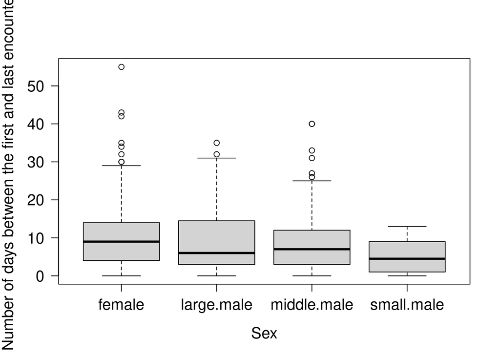

```r
new.all.capt2<-new.all.capt[new.all.capt$no.recaptures>0,]


boxplot(new.all.capt2$days~new.all.capt2$sex.cat,xlab="Sex",ylab="Number of days between the first and last encounter",las=1, lwd=1,font.lab=2, cex.lab=1.3,cex.axis=1.3,font.main=2)
```

```r
new2<-ggplot(new.all.capt2,aes(sex.cat,days),line.thickness=1.2) +theme_classic(base_size = 18) + geom_jitter(width=0.2,alpha=0.5)+scale_y_continuous(name="Number of days between the first and last encounter",breaks= pretty_breaks()) +theme (axis.text.x = element_text(face = "bold", size=12,colour="black"), axis.text.y = element_text(face = "bold", size = 12,colour="black"),panel.border= element_rect(color = "black",fill=NA,size=1), legend.text=element_text(size=14),legend.title=element_text(size=16))
```

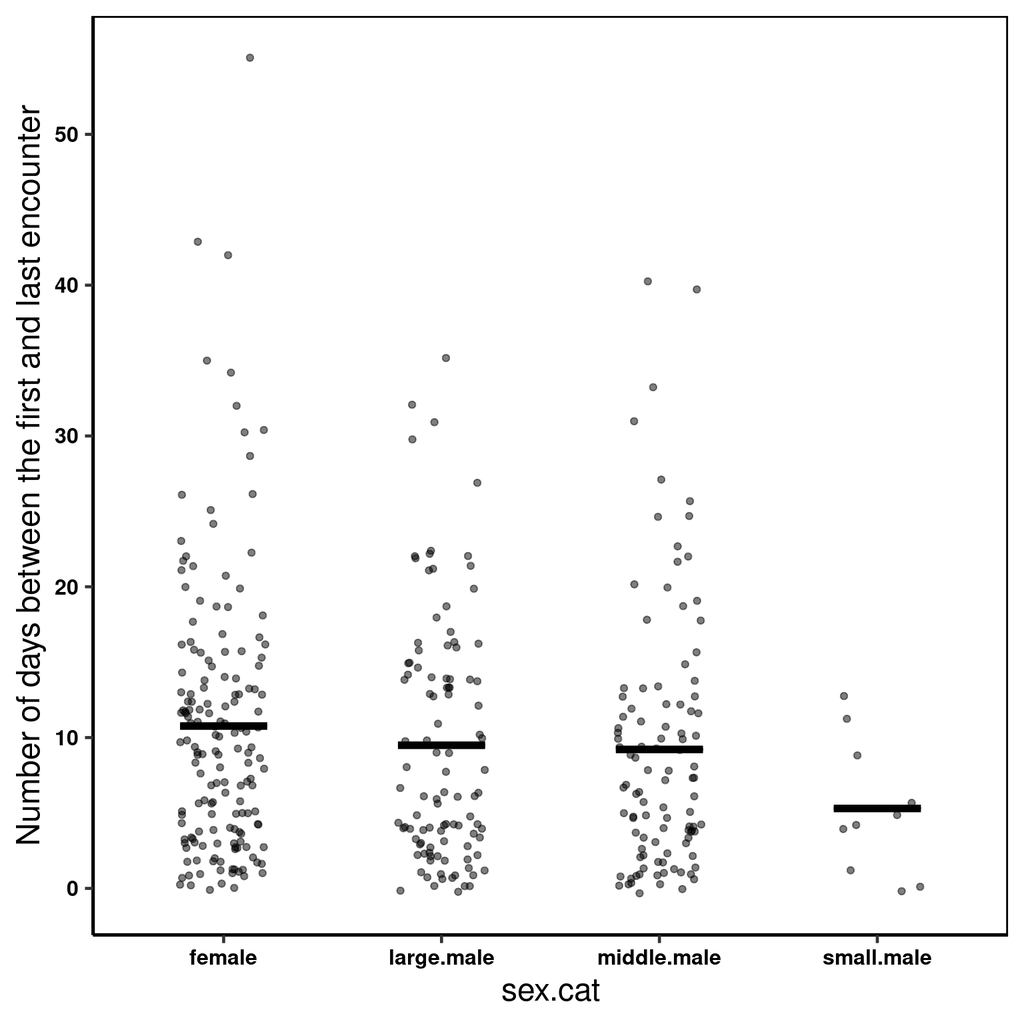

```r
new.plot2<-new.all.capt2[,c(6,13)]
new.plot2.sum<-aggregate(.~sex.cat,mean,data=new.plot2)



new2+ theme(plot.title.position = "plot")+geom_crossbar(data=new.plot2.sum, aes(ymin=days,ymax=days),size=0.8,width=0.4)
```

##### Lets see now the effect size:

```r
rsq.partial(new.nb.days1,type='kl')
```

```
## $adjustment
## [1] FALSE
##
## $variable
## [1] "sex.cat"       "no.recaptures"
##
## $partial.rsq
## [1] 0.01774643 0.05926922
```

##### We can calculate R2 values for Hurdle models by using the function r2_zeroinflated of performance package. It is used for models with zero-inflation component, including mixed effects models. Hurdle and zeroinfl functions by Achim Zeileis

```r
library(performance)
r2_zeroinflated(new.hnb.days1)
```

```
## # R2 for Zero-Inflated and Hurdle Regression
##        R2: 0.914
##   adj. R2: 0.913
```

```r
r2(new.hnb.rec)
```

```
## # R2 for Zero-Inflated and Hurdle Regression
##        R2: 0.009
##   adj. R2: 0.006
```

##### Females and male morphs showed also a small effect size: 0.018.

```r
ph.test.days<-emmeans(new.nb.days1, ~sex.cat,type="response")
test(ph.test.days)
```

```
##  sex.cat     response    SE  df null z.ratio p.value
##  female         10.78 0.731 Inf    1  35.059  <.0001
##  large.male      8.76 0.754 Inf    1  25.210  <.0001
##  middle.male     9.01 0.773 Inf    1  25.620  <.0001
##  small.male      5.66 1.638 Inf    1   5.992  <.0001
##
## Tests are performed on the log scale
```

```r
pairs(ph.test.days)
```

```
##  contrast                 ratio    SE  df null z.ratio p.value
##  female / large.male      1.231 0.135 Inf    1   1.887  0.2334
##  female / middle.male     1.197 0.131 Inf    1   1.643  0.3545
##  female / small.male      1.904 0.565 Inf    1   2.168  0.1322
##  large.male / middle.male 0.972 0.118 Inf    1  -0.230  0.9957
##  large.male / small.male  1.547 0.468 Inf    1   1.443  0.4727
##  middle.male / small.male 1.591 0.480 Inf    1   1.538  0.4146
##
## P value adjustment: tukey method for comparing a family of 4 estimates
## Tests are performed on the log scale
```

```r
contrast(ph.test.days)
```

```
##  contrast           ratio    SE  df null z.ratio p.value
##  female effect       1.29 0.121 Inf    1   2.761  0.0231
##  large.male effect   1.05 0.106 Inf    1   0.496  0.6200
##  middle.male effect  1.08 0.109 Inf    1   0.777  0.5827
##  small.male effect   0.68 0.149 Inf    1  -1.756  0.1582
##
## P value adjustment: fdr method for 4 tests
## Tests are performed on the log scale
```

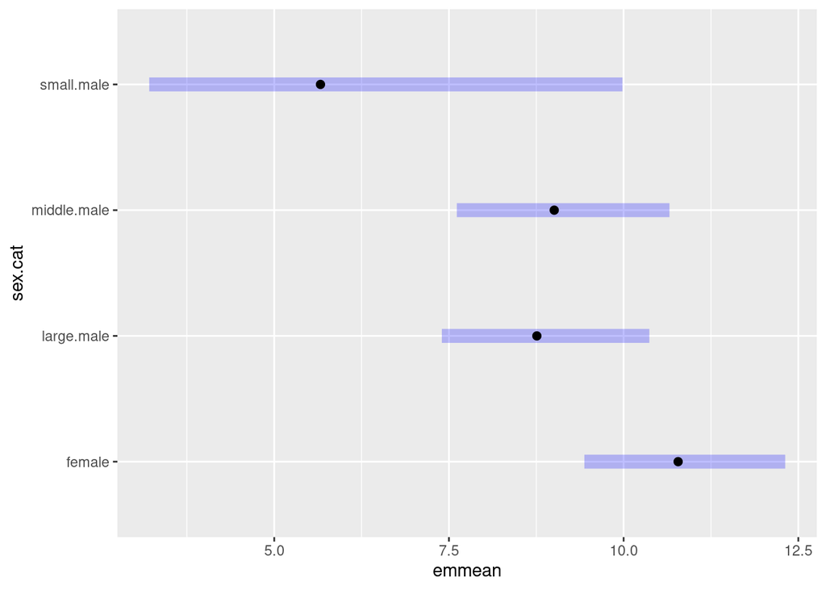

```r
plot(ph.test.days)
```

```r
ph.test.days2<-emmeans(new.nb.days1, ~sex.cat,type="link")
test(ph.test.days2)
```

```
##  sex.cat     emmean     SE  df z.ratio p.value
##  female        2.38 0.0678 Inf  35.059  <.0001
##  large.male    2.17 0.0861 Inf  25.210  <.0001
##  middle.male   2.20 0.0858 Inf  25.620  <.0001
##  small.male    1.73 0.2894 Inf   5.992  <.0001
##
## Results are given on the log (not the response) scale.
```

```r
pairs(ph.test.days2)
```

```
##  contrast                 estimate    SE  df z.ratio p.value
##  female - large.male         0.208 0.110 Inf   1.887  0.2334
##  female - middle.male        0.180 0.109 Inf   1.643  0.3545
##  female - small.male         0.644 0.297 Inf   2.168  0.1322
##  large.male - middle.male   -0.028 0.121 Inf  -0.230  0.9957
##  large.male - small.male     0.436 0.302 Inf   1.443  0.4727
##  middle.male - small.male    0.464 0.302 Inf   1.538  0.4146
##
## Results are given on the log (not the response) scale.
## P value adjustment: tukey method for comparing a family of 4 estimates
```

```r
contrast(ph.test.days2)
```

```
##  contrast           estimate     SE  df z.ratio p.value
##  female effect        0.2578 0.0934 Inf   2.761  0.0231
##  large.male effect    0.0501 0.1011 Inf   0.496  0.6200
##  middle.male effect   0.0781 0.1005 Inf   0.777  0.5827
##  small.male effect   -0.3861 0.2199 Inf  -1.756  0.1582
##
## Results are given on the log (not the response) scale.
## P value adjustment: fdr method for 4 tests
```

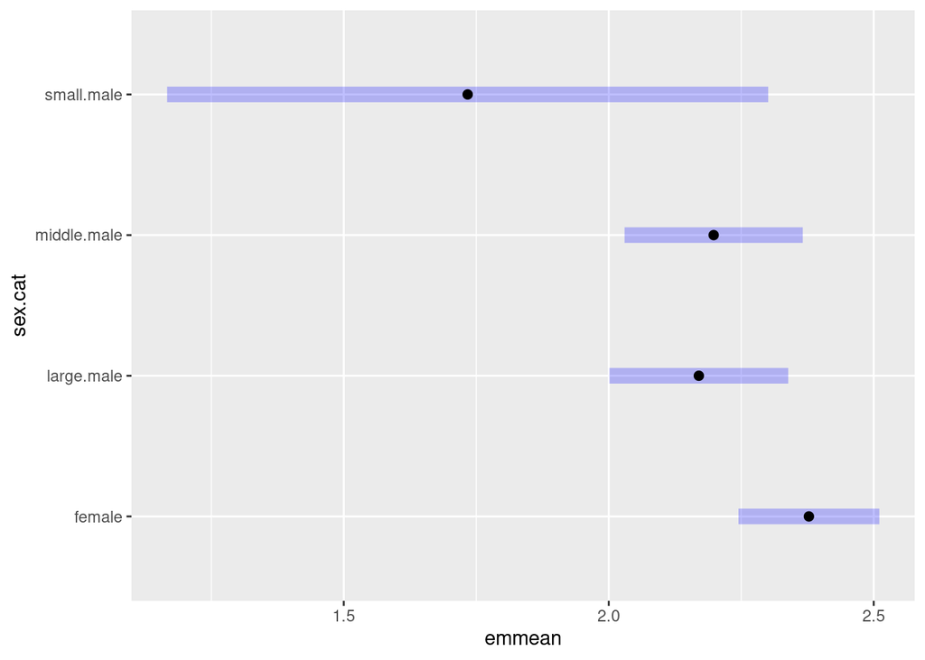

```r
plot(ph.test.days2)
```

#### New analyses of distances travelled between two encounters

```r
colnames(new.all.dist)
```

```
##  [1] "id"                 "no.cap"             "sex"
##  [4] "age"                "aktiv"              "date"
##  [7] "cap.recap"          "comment"            "x.coord"
## [10] "y.coord"            "elev.map.b"         "Distance"
## [13] "body"               "proc"               "date.of.catch"
## [16] "id.1"               "diff.days"          "rel.bodywidth"
## [19] "st.date"            "day"                "day.from.1st.catch"
## [22] "sex.cat"
```

```r
str(new.all.dist)
```

```
## 'data.frame':    683 obs. of  22 variables:
##  $ id                : int  3 35 37 37 46 48 48 55 55 55 ...
##  $ no.cap            : int  2 2 3 4 2 3 2 2 5 6 ...
##  $ sex               : chr  "f" "f" "f" "f" ...
##  $ age               : chr  "juvenil" "juvenil" "juvenil" "juvenil" ...
##  $ aktiv             : chr  "" "dig" "travelled" "travelled" ...
##  $ date              : chr  "2016-03-30" "2016-03-21" "2016-03-30" "2016-04-07" ...
##  $ cap.recap         : chr  "r" "r" "r" "r" ...
##  $ comment           : chr  "died" "" "" "" ...
##  $ x.coord           : num  738888 738823 738783 738782 738907 ...
##  $ y.coord           : num  326513 326586 326601 326608 326540 ...
##  $ elev.map.b        : num  221 244 248 248 225 ...
##  $ Distance          : num  1.69 2.02 9.4 6.79 5.44 ...
##  $ body              : num  12.1 12.2 10.7 10.7 10.7 ...
##  $ proc              : num  0 0 0 0 0 0 0 0 0 0 ...
##  $ date.of.catch     : chr  "2016-03-17" "2016-03-18" "2016-03-18" "2016-03-18" ...
##  $ id.1              : int  3 35 37 37 46 48 48 55 55 55 ...
##  $ diff.days         : num  13 3 12 8 42 9 1 8 1 1 ...
##  $ rel.bodywidth     : num  0.507 0.664 -1.484 -1.484 -1.512 ...
##  $ st.date           : chr  "2016-03-17" "2016-03-17" "2016-03-17" "2016-03-17" ...
##  $ day               : int  13 4 13 21 46 14 13 12 15 16 ...
##  $ day.from.1st.catch: int  0 1 1 1 4 4 4 4 4 4 ...
##  $ sex.cat           : chr  "female" "female" "female" "female" ...
```

```r
library(lme4)
dist.new<-lmer(log(Distance+1) ~ (sex.cat+day+diff.days)^2+(1|id),data=new.all.dist)
print(summary(dist.new),correlation=TRUE)
```

```
## Linear mixed model fit by REML ['lmerMod']
## Formula: log(Distance + 1) ~ (sex.cat + day + diff.days)^2 + (1 | id)
##    Data: new.all.dist
##
## REML criterion at convergence: 1953.6
##
## Scaled residuals:
##     Min      1Q  Median      3Q     Max
## -2.2789 -0.6031 -0.1551  0.4390  4.2772
##
## Random effects:
##  Groups   Name        Variance Std.Dev.
##  id       (Intercept) 0.1345   0.3668
##  Residual             0.8054   0.8975
## Number of obs: 683, groups:  id, 380
##
## Fixed effects:
##                                Estimate Std. Error t value
## (Intercept)                   1.9385518  0.1742625  11.124
## sex.catlarge.male            -0.5022230  0.2190124  -2.293
## sex.catmiddle.male           -0.5395844  0.2232307  -2.417
## sex.catsmall.male             1.5368411  0.6674085   2.303
## day                          -0.0115149  0.0049385  -2.332
## diff.days                     0.0179944  0.0202558   0.888
## sex.catlarge.male:day         0.0121872  0.0072527   1.680
## sex.catmiddle.male:day        0.0302575  0.0081500   3.713
## sex.catsmall.male:day        -0.0260698  0.0170271  -1.531
## sex.catlarge.male:diff.days   0.0149620  0.0165896   0.902
## sex.catmiddle.male:diff.days  0.0068818  0.0163258   0.422
## sex.catsmall.male:diff.days  -0.0331170  0.0733249  -0.452
## day:diff.days                 0.0004936  0.0004112   1.200
```

```
##
## Correlation of fixed effects could have been required in summary()
```

```
##
## Correlation of Fixed Effects:
##             (Intr) sx.ctl. sx.ctm. sx.cts. day    dff.dy sx.ctl.: sx.ctm.:
## sx.ctlrg.ml -0.650
## sx.ctmddl.m -0.560  0.436
## sx.ctsmll.m -0.238  0.162   0.145
## day         -0.846  0.531   0.446   0.199
## diff.days   -0.518  0.180   0.054   0.099   0.311
## sx.ctlrg.m:  0.410 -0.785  -0.293  -0.104  -0.520  0.051
## sx.ctmddl.:  0.295 -0.252  -0.782  -0.080  -0.395  0.158  0.288
## sx.ctsmll.:  0.197 -0.139  -0.126  -0.768  -0.244 -0.014  0.145    0.120
## sx.ctlrg.:.  0.181 -0.094  -0.035  -0.036   0.058 -0.504 -0.363   -0.140
## sx.ctmdd.:.  0.115 -0.053   0.053  -0.024   0.126 -0.402 -0.129   -0.512
## sx.ctsml.:.  0.077 -0.028  -0.010  -0.437  -0.021 -0.171 -0.023   -0.036
## day:dff.dys  0.556 -0.180  -0.037  -0.104  -0.539 -0.883  0.070   -0.065
##             sx.cts.: sx.ctl.:. sx.ctm.:. sx.cts.:.
## sx.ctlrg.ml
## sx.ctmddl.m
## sx.ctsmll.m
## day
## diff.days
## sx.ctlrg.m:
## sx.ctmddl.:
## sx.ctsmll.:
## sx.ctlrg.:. -0.040
## sx.ctmdd.:. -0.049    0.372
## sx.ctsml.:. -0.047    0.107     0.093
## day:dff.dys  0.070    0.267     0.146     0.124
```

```r
drop1(dist.new,test="Chisq")
```

```
## Single term deletions
##
## Model:
## log(Distance + 1) ~ (sex.cat + day + diff.days)^2 + (1 | id)
##                   npar    AIC     LRT   Pr(Chi)
## <none>                 1901.3
## sex.cat:day          3 1914.0 18.6306 0.0003259 ***
## sex.cat:diff.days    3 1896.5  1.1630 0.7618808
## day:diff.days        1 1900.8  1.4399 0.2301586
## ---
## Signif. codes:  0 '***' 0.001 '**' 0.01 '*' 0.05 '.' 0.1 ' ' 1
```

```r
dist.new2<-update(dist.new,.~.-sex.cat:diff.days)
summary(dist.new2)
```

```
## Linear mixed model fit by REML ['lmerMod']
## Formula:
## log(Distance + 1) ~ sex.cat + day + diff.days + (1 | id) + sex.cat:day +
##     day:diff.days
##    Data: new.all.dist
##
## REML criterion at convergence: 1938.4
##
## Scaled residuals:
##     Min      1Q  Median      3Q     Max
## -2.3334 -0.6027 -0.1546  0.4510  4.3334
##
## Random effects:
##  Groups   Name        Variance Std.Dev.
##  id       (Intercept) 0.1347   0.367
##  Residual             0.8028   0.896
## Number of obs: 683, groups:  id, 380
##
## Fixed effects:
##                          Estimate Std. Error t value
## (Intercept)             1.9144623  0.1706806  11.217
## sex.catlarge.male      -0.4850173  0.2177234  -2.228
## sex.catmiddle.male     -0.5350722  0.2222621  -2.407
## sex.catsmall.male       1.3979334  0.5996578   2.331
## day                    -0.0119203  0.0048896  -2.438
## diff.days               0.0264486  0.0167016   1.584
## sex.catlarge.male:day   0.0146195  0.0067489   2.166
## sex.catmiddle.male:day  0.0316974  0.0069783   4.542
## sex.catsmall.male:day  -0.0258004  0.0169677  -1.521
## day:diff.days           0.0004144  0.0003934   1.053
##
## Correlation of Fixed Effects:
##             (Intr) sx.ctl. sx.ctm. sx.cts. day    dff.dy sx.ctl.: sx.ctm.:
## sx.ctlrg.ml -0.646
## sx.ctmddl.m -0.570  0.438
## sx.ctsmll.m -0.235  0.169   0.156
## day         -0.885  0.546   0.445   0.210
## diff.days   -0.505  0.154   0.062   0.044   0.443
## sx.ctlrg.m:  0.520 -0.883  -0.330  -0.132  -0.541 -0.167
## sx.ctmddl.:  0.411 -0.322  -0.880  -0.113  -0.389 -0.037  0.301
## sx.ctsmll.:  0.213 -0.145  -0.126  -0.878  -0.241 -0.057  0.141    0.113
## day:dff.dys  0.532 -0.160  -0.032  -0.062  -0.587 -0.920  0.184   -0.004
##             sx.cts.:
## sx.ctlrg.ml
## sx.ctmddl.m
## sx.ctsmll.m
## day
## diff.days
## sx.ctlrg.m:
## sx.ctmddl.:
## sx.ctsmll.:
## day:dff.dys  0.091
```

```r
drop1(dist.new2,test="Chisq")
```

```
## Single term deletions
##
## Model:
## log(Distance + 1) ~ sex.cat + day + diff.days + (1 | id) + sex.cat:day +
##     day:diff.days
##               npar    AIC     LRT   Pr(Chi)
## <none>             1896.5
## sex.cat:day      3 1916.4 25.8849 1.008e-05 ***
## day:diff.days    1 1895.6  1.0964    0.2951
## ---
## Signif. codes:  0 '***' 0.001 '**' 0.01 '*' 0.05 '.' 0.1 ' ' 1
```

```r
dist.new3<-update(dist.new2,.~.-day:diff.days)
summary(dist.new3)
```

```
## Linear mixed model fit by REML ['lmerMod']
## Formula: log(Distance + 1) ~ sex.cat + day + diff.days + (1 | id) + sex.cat:day
##    Data: new.all.dist
##
## REML criterion at convergence: 1925.6
##
## Scaled residuals:
##     Min      1Q  Median      3Q     Max
## -2.1833 -0.6108 -0.1539  0.4516  4.2377
##
## Random effects:
##  Groups   Name        Variance Std.Dev.
##  id       (Intercept) 0.1312   0.3623
##  Residual             0.8056   0.8976
## Number of obs: 683, groups:  id, 380
##
## Fixed effects:
##                         Estimate Std. Error t value
## (Intercept)             1.819640   0.144253  12.614
## sex.catlarge.male      -0.450426   0.214543  -2.099
## sex.catmiddle.male     -0.528927   0.221790  -2.385
## sex.catsmall.male       1.433729   0.597626   2.399
## day                    -0.008917   0.003955  -2.254
## diff.days               0.042671   0.006563   6.502
## sex.catlarge.male:day   0.013334   0.006627   2.012
## sex.catmiddle.male:day  0.031728   0.006972   4.551
## sex.catsmall.male:day  -0.027356   0.016875  -1.621
##
## Correlation of Fixed Effects:
##             (Intr) sx.ctl. sx.ctm. sx.cts. day    dff.dy sx.ctl.: sx.ctm.:
## sx.ctlrg.ml -0.672
## sx.ctmddl.m -0.653  0.438
## sx.ctsmll.m -0.239  0.161   0.154
## day         -0.835  0.565   0.527   0.215
## diff.days   -0.047  0.019   0.084  -0.032  -0.305
## sx.ctlrg.m:  0.507 -0.880  -0.329  -0.123  -0.543  0.006
## sx.ctmddl.:  0.488 -0.327  -0.881  -0.113  -0.483 -0.104  0.307
## sx.ctsmll.:  0.196 -0.133  -0.124  -0.878  -0.233  0.067  0.127    0.114
```

```r
drop1(dist.new3,test="Chisq")
```

```
## Single term deletions
##
## Model:
## log(Distance + 1) ~ sex.cat + day + diff.days + (1 | id) + sex.cat:day
##             npar    AIC    LRT   Pr(Chi)
## <none>           1895.6
## diff.days      1 1935.0 41.343 1.278e-10 ***
## sex.cat:day    3 1915.6 25.957 9.739e-06 ***
## ---
## Signif. codes:  0 '***' 0.001 '**' 0.01 '*' 0.05 '.' 0.1 ' ' 1
```

Compare “stats drop1” to “glmmTMB drop1”:

```r
library(glmmTMB)
dist.new.tmb<-glmmTMB(log(Distance+1) ~ sex.cat:day+diff.days+(1|id),family="gaussian",data=new.all.dist)
summary(dist.new.tmb)
```

```
##  Family: gaussian  ( identity )
## Formula:          log(Distance + 1) ~ sex.cat:day + diff.days + (1 | id)
## Data: new.all.dist
##
##      AIC      BIC   logLik deviance df.resid
##   1905.3   1941.5   -944.6   1889.3      675
##
## Random effects:
##
## Conditional model:
##  Groups   Name        Variance Std.Dev.
##  id       (Intercept) 0.1486   0.3854
##  Residual             0.8008   0.8949
## Number of obs: 683, groups:  id, 380
##
## Dispersion estimate for gaussian family (sigma^2): 0.801
##
## Conditional model:
##                         Estimate Std. Error z value Pr(>|z|)
## (Intercept)             1.563613   0.090100  17.354  < 2e-16 ***
## diff.days               0.044462   0.006599   6.738 1.61e-11 ***
## sex.catfemale:day      -0.003375   0.003025  -1.116 0.264594
## sex.catlarge.male:day  -0.001696   0.003967  -0.428 0.668907
## sex.catmiddle.male:day  0.014117   0.004210   3.353 0.000798 ***
## sex.catsmall.male:day   0.005551   0.008295   0.669 0.503397
## ---
## Signif. codes:  0 '***' 0.001 '**' 0.01 '*' 0.05 '.' 0.1 ' ' 1
```

```r
drop1(dist.new.tmb,test="Chisq")
```

```
## Single term deletions
##
## Model:
## log(Distance + 1) ~ sex.cat:day + diff.days + (1 | id)
##             Df    AIC    LRT  Pr(>Chi)
## <none>         1905.3
## diff.days    1 1947.2 43.879 3.493e-11 ***
## sex.cat:day  4 1926.8 29.555 6.028e-06 ***
## ---
## Signif. codes:  0 '***' 0.001 '**' 0.01 '*' 0.05 '.' 0.1 ' ' 1
```

```r
ph.dist.new<-emmeans::emtrends(dist.new3,~1,"diff.days")
test(ph.dist.new)
```

```
##  1       diff.days.trend      SE  df t.ratio p.value
##  overall          0.0427 0.00657 671   6.490  <.0001
##
## Results are averaged over the levels of: sex.cat
## Degrees-of-freedom method: kenward-roger
```

```
## Using data new.all.dist from global environment. This could cause incorrect
## results if new.all.dist has been altered since the model was fit. You can
## manually provide the data to the "data =" argument.
```

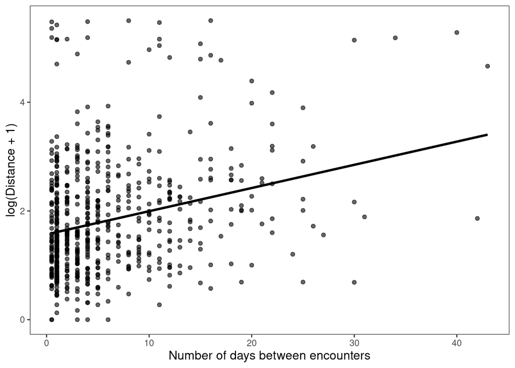

```r
effect_plot(dist.new3, pred = diff.days, interval = FALSE, plot.points = TRUE,x.label="Number of days between encounters")+ theme_apa()
```

```r
ph.dist.new2<-emtrends(dist.new3,~sex.cat,"day")
test(ph.dist.new2)
```

```
##  sex.cat     day.trend      SE  df t.ratio p.value
##  female       -0.00892 0.00397 524  -2.249  0.0249
##  large.male    0.00442 0.00559 549   0.791  0.4295
##  middle.male   0.02281 0.00614 576   3.713  0.0002
##  small.male   -0.03627 0.01642 431  -2.208  0.0277
##
## Degrees-of-freedom method: kenward-roger
```

```r
pairs(ph.dist.new2)
```

```
##  contrast                 estimate      SE  df t.ratio p.value
##  female - large.male       -0.0133 0.00664 517  -2.007  0.1866
##  female - middle.male      -0.0317 0.00699 537  -4.540  <.0001
##  female - small.male        0.0274 0.01689 435   1.620  0.3687
##  large.male - middle.male  -0.0184 0.00803 549  -2.291  0.1013
##  large.male - small.male    0.0407 0.01734 442   2.346  0.0894
##  middle.male - small.male   0.0591 0.01753 447   3.371  0.0045
##
## Note: contrasts are still on the 1(mu + 1) scale
## Degrees-of-freedom method: kenward-roger
## P value adjustment: tukey method for comparing a family of 4 estimates
```

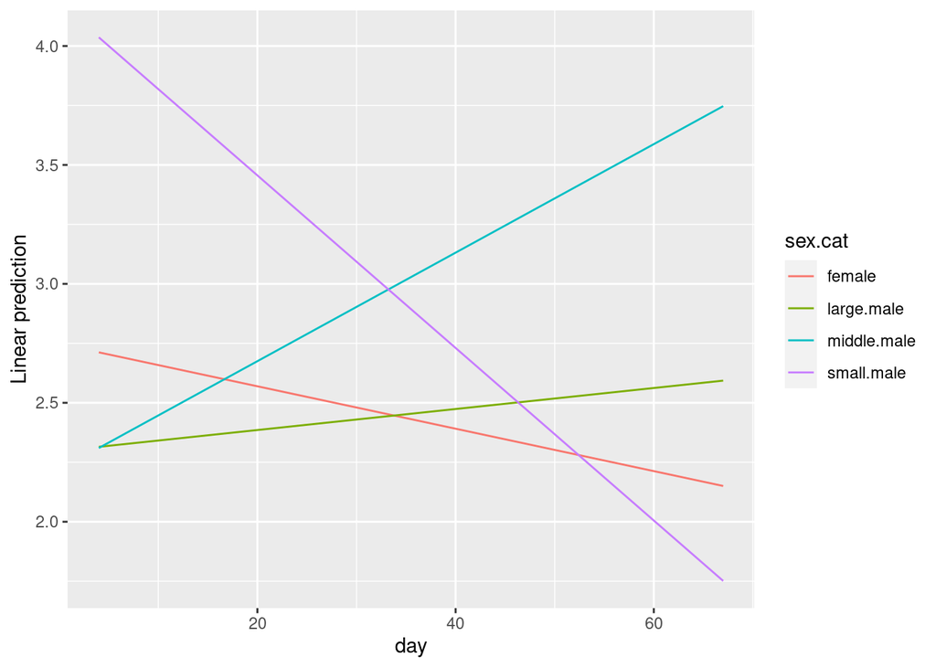

```r
emmip(dist.new3,sex.cat~day,cov.reduce=range)
```

##### Small males seem to travel and move similarly to the females.

##### Lets visualise the results.

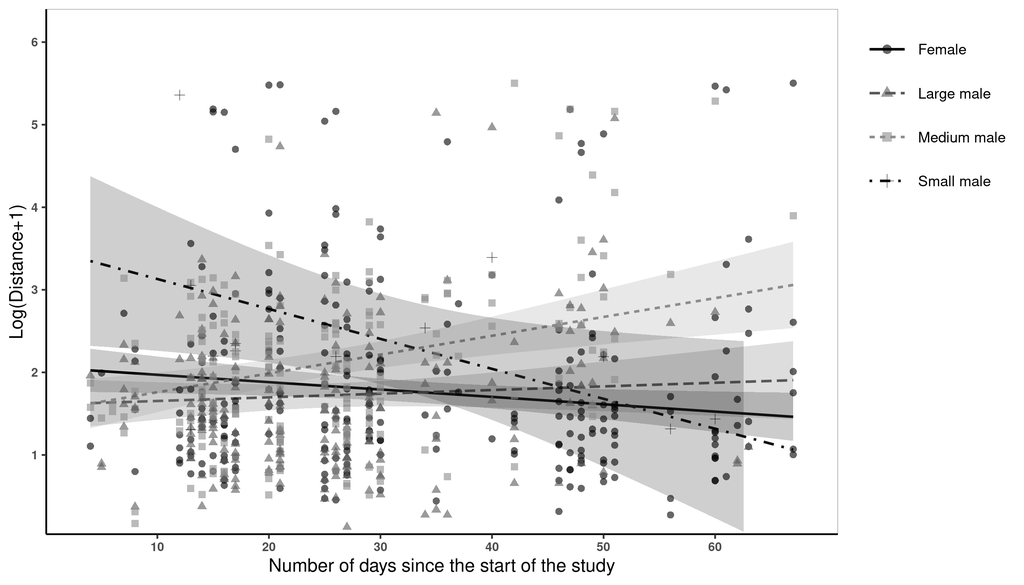

```r
new.dist1<-interact_plot(dist.new3, pred = day, modx = sex.cat,x.label="Number of days since the start of the study",data=new.all.dist,y.label="Log(Distance+1)",lwd=2,line.thickness=1.2,colors=c("black","grey35","grey55","grey6"),plot.points=TRUE,point.shape=T,point.size=3,interval = TRUE,  int.type = "confidence", int.width = .95,modx.labels=c("Female","Large male","Medium male","Small male")) + theme_apa()+theme_classic(base_size = 18)+theme(legend.title=element_blank(),legend.key.size = unit(3, "lines"),legend.position="right",legend.justification = "top")+guides(fill = guide_legend(override.aes = list(size=4)))+ scale_x_continuous(limits=c(0.04,71),expand=c(0,0),breaks=c(10,20,30,40,50,60)) + scale_y_continuous(limits=c(0.04,6.4), expand=c(0,0),breaks=c(1,2,3,4,5,6))



new.dist1 + theme (axis.text.x = element_text(face = "bold", size=12),  axis.text.y = element_text(face = "bold", size = 12),panel.border = element_rect(colour = "black", fill=NA, size=0.2))
```

##### Create colourfull plots for graphical abstract:

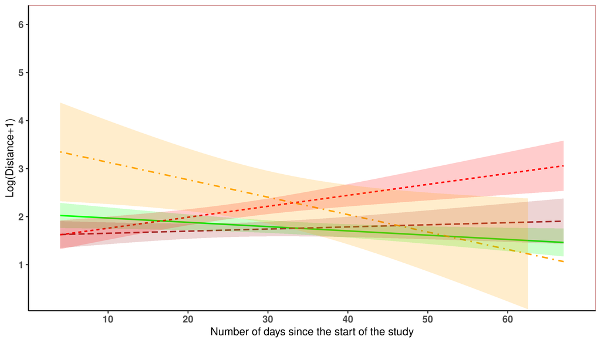

```r
new.dist.col<-interact_plot(dist.new3, pred = day, modx = sex.cat,x.label="Number of days since the start of the study",data=new.all.dist,y.label="Log(Distance+1)",lwd=2,line.thickness=1.2,colors=c("green","brown","red","orange"),interval = TRUE, int.type = "confidence", int.width = .95) + theme_apa()+theme_classic(base_size = 18)+ scale_x_continuous(limits=c(0.04,71),expand=c(0,0),breaks=c(10,20,30,40,50,60)) + scale_y_continuous(limits=c(0.04,6.4), expand=c(0,0),breaks=c(1,2,3,4,5,6))+theme(legend.position = "none")



new.dist.col + theme (axis.text.x = element_text(face = "bold", size=16),  axis.text.y = element_text(face = "bold", size = 16),panel.border = element_rect(colour = "brown", fill=NA, size=0.5))
```

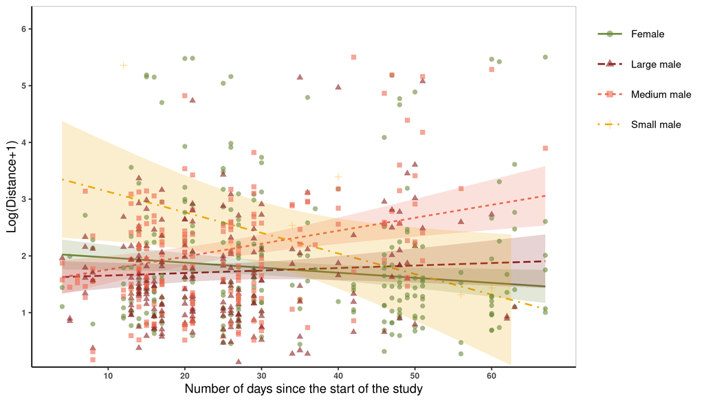

```r
new.dist.col2<-interact_plot(dist.new3, pred = day, modx = sex.cat,x.label="Number of days since the start of the study",data=new.all.dist,y.label="Log(Distance+1)",lwd=2,line.thickness=1.2,colors=c("darkolivegreen4","brown4","coral2","darkgoldenrod2"),,plot.points=TRUE,point.shape=T,point.size=3,interval = TRUE,  int.type = "confidence", int.width = .95,modx.labels=c("Female","Large male","Medium male","Small male")) + theme_apa()+theme_classic(base_size = 18)+theme(legend.title=element_blank(),legend.key.size = unit(3, "lines"),legend.position="right",legend.justification = "top")+guides(fill = guide_legend(override.aes = list(size=4)))+ scale_x_continuous(limits=c(0.04,71),expand=c(0,0),breaks=c(10,20,30,40,50,60)) + scale_y_continuous(limits=c(0.04,6.4), expand=c(0,0),breaks=c(1,2,3,4,5,6))



new.dist.col2 + theme (axis.text.x = element_text(face = "bold", size=12),  axis.text.y = element_text(face = "bold", size = 12),panel.border = element_rect(colour = "black", fill=NA, size=0.2))
```

##### Lets see effect sizes:

```r
partR2(dist.new3, partvars= c("diff.days","sex.cat:day"),R2_type="conditional",nboot = 100, CI = 0.95)
```

```
##
##
## R2 (conditional) and 95% CI for the full model:
##  R2     CI_lower CI_upper nboot ndf
##  0.2625 0.1813   0.3512   100   9
##
## ----------
##
## Part (semi-partial) R2:
##  Predictor(s)          R2     CI_lower CI_upper nboot ndf
##  Model                 0.2625 0.1813   0.3512   100   9
##  diff.days             0.1737 0.0906   0.2642   100   8
##  sex.cat:day           0.1531 0.0694   0.2437   100   6
##  diff.days+sex.cat:day 0.2182 0.1361   0.3082   100   5
```

```r
partR2(dist.new3, partvars= c("diff.days","sex.cat:day"),R2_type="marginal",nboot = 100, CI = 0.95)
```

```
##
##
## R2 (marginal) and 95% CI for the full model:
##  R2     CI_lower CI_upper nboot ndf
##  0.1423 0.1099   0.2025   100   9
##
## ----------
##
## Part (semi-partial) R2:
##  Predictor(s)          R2     CI_lower CI_upper nboot ndf
##  Model                 0.1423 0.1099   0.2025   100   9
##  diff.days             0.0535 0.0214   0.1128   100   8
##  sex.cat:day           0.0330 0.0011   0.0923   100   6
##  diff.days+sex.cat:day 0.0981 0.0660   0.1577   100   5
```

##### Lets create a plot for the first two models:

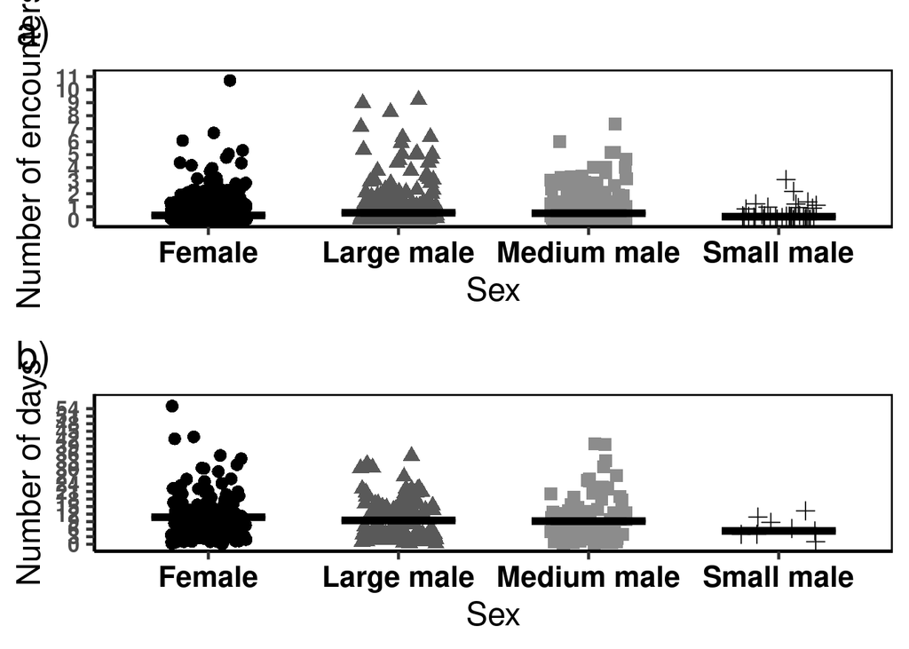

```r
d.plot1<-new.all.capt[,c(8,13)]
d.plot1.sum<-aggregate(.~sex.cat,mean,data=d.plot1)

p1new<-ggplot(d.plot1,aes(sex.cat,no.recaptures),line.thickness=1.2) +theme_classic(base_size = 18)+geom_point(position=position_jitter(width=0.2),size=3,aes(shape=sex.cat,x = sex.cat, y = no.recaptures,color=sex.cat))+
scale_y_continuous(name="Number of encounters",limits=c(0,11),breaks= round(seq(min(new.all.capt$no.recaptures),max(new.all.capt$no.recaptures),by=1),1)) +  labs(x="Sex")+scale_x_discrete(labels=c("Female","Large male","Medium male", "Small male"))+theme (axis.text.x = element_text(face = "bold", size=16,colour="black"), axis.text.y = element_text(face = "bold", size = 12),panel.border= element_rect(color ="black",fill=NA,size=1))+geom_crossbar(data=d.plot1.sum, aes(ymin=no.recaptures,ymax=no.recaptures),size=0.8,width=0.6)+theme(legend.position = "none")+ scale_color_manual(values = c("black","grey35","grey55","grey6"))

p1t<-p1new+labs(title = "a)") + theme(plot.title.position = "plot")+geom_crossbar(data=d.plot1.sum, aes(ymin=no.recaptures,ymax=no.recaptures),size=0.8,width=0.4)

d.plot<-new.all.capt2[,c(6,13)]
d.plot.sum<-aggregate(.~sex.cat,mean,data=d.plot)

p2<-ggplot(d.plot,aes(sex.cat,days),line.thickness=1.2) +theme_classic(base_size = 18)+geom_point(position=position_jitter(width=0.2),size=3,aes(shape=sex.cat,x = sex.cat, y = days, color = sex.cat))+
scale_y_continuous(name="Number of days",limits=c(0,57),breaks= round(seq(min(new.all.capt2$days),max(new.all.capt2$days),by=3),1)) +  labs(x="Sex")+scale_x_discrete(labels=c("Female","Large male","Medium male", "Small male"))+theme (axis.text.x = element_text(face = "bold", size=16,colour="black"), axis.text.y = element_text(face = "bold", size = 12),panel.border= element_rect(color ="black",fill=NA,size=1))+geom_crossbar(data=d.plot.sum, aes(ymin=days,ymax=days),size=0.8,width=0.6)+theme(legend.position = "none")+ scale_color_manual(values = c("black","grey35","grey55","grey6"))


p2t<-p2+labs(title = "b)") + theme(plot.title.position = "plot")+geom_crossbar(data=d.plot.sum, aes(ymin=days,ymax=days),size=0.8,width=0.4)

library(gridExtra)
grid.arrange(p1t, p2t, nrow=2)
```

```r
table(new.all.capt$sex.cat,new.all.capt$no.recaptures)
```

```
##
##                 0   1   2   3   4   5   6   7   8   9  11
##   female      626 118  24   8   5   3   1   1   0   0   2
##   large.male  311  61  17   8   4   7   3   1   1   2   0
##   middle.male 263  64  16  14   4   3   1   1   0   0   0
##   small.male   45   8   1   1   0   0   0   0   0   0   0
```